# RSelenium Intro

jojoecp

24/11/2020

In this markdown we will learn to do web scraping using RSelenium. RSelenium provides R bindings for the Selenium Webdriver API. Selenium is a project focused on automating web browsers. RSelenium allows you to carry out unit testing and regression testing on your webapps and webpages across a range of browser/OS combinations. You can access full vignettes of RSelenium [here](https://cran.r-project.org/web/packages/RSelenium/vignettes/basics.html).

R also provide web scrapping tools like the famous `rvest` but RSelenium gives more advantages thant rvest, for example:  
- Java scripted web scrapping  
- Running on selenium server with [Docker](https://www.docker.com/) container  
- Running on local by Webdriver Manager or [wdman](https://docs.ropensci.org/wdman/) wrapper  
- Injectting java script to transform HTML structure  
- Sending Events to elements (click, choose dropdown menu, scrolling, sending text, etc.)  
- Live browsing navigation

Web scrapinging is just on of various data gathering technique. Why it’s important to do data gathering? well.. doesn’t matter how ‘expert’ you’re as data scientist, if there’s no data, what you gonna do?

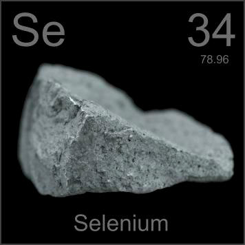

# 1 Background

## 1.1 Objective

The goal(s) from this project is **gather information as much as possible** from [Shopee](https://shopee.co.id/) product review. Shopee is a well-known marketplace in Indonesia and Asia. Every content in Shopee website are built using java script so its almost imposible to do web scraping using HTML page source based tools like Rvest. We also want to do custom interaction like clicking next button or scrolling through the review. We’ll scrapp all product with keyword **Iphone X** in Smartphone category. After we scrap the data, we will try to do a simple EDA to gain new information from the product reviews.

If you have no idea what is the difference between java scripted web than regular ones, you can try to scrap the shopee page using rvest and you will found nothing

```r
library(rvest)
main <- "https://shopee.co.id/search?category=40&keyword=iphone%20x&subcategory=1211"
read_test <- read_html(main)
html_nodes(read_test,"a")
```

```
## {xml_nodeset (0)}
```

In this case, you need to use web browser simulation tools like Selenium

## 1.2 Libraries

You can load the package into your workspace using the library() function

```r
library(tidyverse)
library(rvest)
library(RSelenium)
```

# 2 Let’s begin

## 2.1 Prerequisites

From the vignettes, the author of RSelenium suggest to run selenium server by using Docker container rather than standalone binary. But is kinda hard to integrate Docker in our local pc and not all device (read: potato pc) can meet docker minimum requirements. So in this article we will run RSelenium with our default local browser. In this case, we will use Chrome

We dont need to install chrome webdriver to use RSelenium because this package provide `rsDriver` function which will manage the binaries needed for running a Selenium Server. In a simple words, it will download and install webdrive (based on your preferences) in your R environment.

First take a look at your chrome version Settings > About Chrome

[figure not shown]

I’m using Version 87.0.4280.66. we need to install webdriver with same version as our default browser. I also provide the main link to scrap the product.

```r
main <- "https://shopee.co.id/search?category=40&keyword=iphone%20x&subcategory=1211"

# install webdriver and launh it in port 4444.
rsDriver(browser = "chrome",chromever = "87.0.4280.20",port = 4444L)
```

you can change the chrome version based on your default browser version. you can see the avaliable version of webdriver using `binman::list_versions()` function.

If there’s a browser popped up, You can ignore the warning message above

[figure not shown]

```r
# assign the remote driver in rmdr object. rmdr will be your browser remote
rmdr <- remoteDriver(browserName = "chrome")
# open the browser
rmdr$open()
# navigate to main link
rmdr$navigate(main)
```

# 3 Information Gathering

## 3.1 Gather Product Pages

The chunk below provides functions to scrap the product. RSelenium also match elements by its css or xpath style. It really works like rvest. So if you already familiar with rvest, you can use selenium easily. Fear not if you don’t. You can learn how rvest works from my previous article [here](https://rpubs.com/jojoecp/635826). The thing is we need to know css/xpath stly from coresponding elements to gather the data or sending event like click or scrolling.

In the chunk below, we combine Rselenium to interact with the browser and rvest to gather the information.

```r
shop <- "https://shopee.co.id"
# how many page you want to scrap
paged <- 10
# link container
link_base <- data.frame()

for(i in 1:paged){
  message("Getting product link #",i,"/",paged)

  # go to main page and wait for 5 second
  if(i == 1){
    rmdr$navigate(main)
    Sys.sleep(10)
    }

  # scroll to bottom and wait for 5 second
  webElem <- rmdr$findElement("css", "body")
  webElem$sendKeysToElement(list(key = "end"))
  Sys.sleep(5)

  # get page source
  pages <- rmdr$getPageSource()[[1]]
  # get link with rvest
  read1 <- read_html(pages)
  linkx <- html_nodes(read1,".shopee-search-item-result__item") %>%
  html_nodes("a") %>% html_attr("href")

  linkget <- paste(shop,linkx,sep = "") %>% data.frame()
  link_base <- rbind(link_base,linkget)

  # next page
  rmdr$findElement("css",".shopee-icon-button--right")$clickElement()
  Sys.sleep(5)
}
```

RSelenium with live browser also have a crucial disadvantage, time. Scraping using Selenium is like running a browser simulation with robot to do the task repeatedly. It takes a lot of time to load a lot of webpages. You can encounter this by using headless browser (Phantomjs) but it needs different vignette that (maybe) i’ll provide later.

```r
# link_product <- link_base %>% distinct() %>%
#   rename("link" = ".")

link_product <- readRDS("data_input/product_link.rds")
head(link_product)
```

|  | link |
| --- | --- |
| 1 | https://shopee.co.id/iPhone-X-256gb-Second-Normal-Fullset-Ex-Inter-free-asuransi-JNE-i.47745953.2055161396 |
| 2 | https://shopee.co.id/iphone-X-64gb-second-fullset-Normal-Ex-Inter-free-asuransi-JNE-i.47745953.1887735183 |
| 3 | https://shopee.co.id/iPhone-X-256Gb-second-fullset-normal-no-face-id-free-asuransi-JNE-i.47745953.5510545590 |
| 4 | https://shopee.co.id/iPhone-X-256GB-64GB-Second-Fulset-MULUS-EX-Inter-Ori-Battery-2-7-8-6-mAh-Silver-Gray-i.61376437.4312219803 |
| 5 | https://shopee.co.id/iphone-x-256gb-second-fullset-ex-inter-NO-FACE-ID-JNE-INSURANCE-INCLUDES-i.73370096.7705786775 |
| 6 | https://shopee.co.id/-TERMURAH-APPLE-IPHONE-X-SECOND-64GB-256GB-GREY-SILVER-ORIGINAL-GARANSI-i.10230608.1586990183 |

## 3.2 Gather Product Review and Details

Same as before, i already build a long function to scrap information including: product name, price, rating, description, and review. every line of code will be explained so you can re-use it on your own project

```r
desc_product <- data.frame()
datt <- data.frame()
review_product <- vector(mode = "list",length = nrow(link_product))


for(i in 213:nrow(link_product)){
  message("Getting product description #",i,"/",nrow(link_product))
  # go to the link in the list
  rmdr$navigate(link_product$link[i])
  Sys.sleep(5)

  # check if rating is exist. if there is no rating we will assume
  # that the product is never been sold and fill the value as "none"
  add_null_a <- FALSE
  tryCatch(rmdr$findElement("css","._2z6cUg")$getElementText(),
           error = function(e){add_null_a <<- TRUE})
  if(add_null_a){rating <- "none"}else{
    # get product rating
    rating <- rmdr$findElement("css","._2z6cUg")$getElementText()[[1]]
  }

  # check if sold is exist. if there is no rating we will assume
  # that the product is never been sold and fill the value as "none"
  add_null_b <- FALSE
  tryCatch(rmdr$findElement("css","._22sp0A")$getElementText(),
           error = function(e){add_null_b <<- TRUE})
  if(add_null_b){sold <- "none"}else{
    # get product sold
    sold <- rmdr$findElement("css","._22sp0A")$getElementText()[[1]]
  }

  # get product name
  name <- rmdr$findElement("css",".qaNIZv span")$getElementText()[[1]]
  # get product price
  price <- rmdr$findElement("css","._3n5NQx")$getElementText()[[1]]
  # get product description
  description <- rmdr$findElement("css","._2u0jt9 span")$getElementText()[[1]]
  # save the product details to dataframe
  temp <- data.frame(Name = name, Rating = rating, Price = price,
                     Sold = sold, desc = description, Link = link_product$link[i])
  desc_product <- rbind(desc_product,temp)

  # review
  ## check how many review are listed. if there is no review,
  ## the loop will skip to next iteration
  add_null_c <- FALSE
  tryCatch(rmdr$findElement("css",".M3KjhJ+ .M3KjhJ ._3Oj5_n")$getElementText(),
           error = function(e){add_null_c <<- TRUE})
  ## if review are existed, count the review to calculate how many
  ## next-button click is needed
  if(add_null_c){next}else{
    rev <- rmdr$findElement("css",".M3KjhJ+ .M3KjhJ ._3Oj5_n")$getElementText() %>%
      unlist() %>% as.numeric()
    rev <- ifelse(rev <= 6, 0, ifelse(rev <= 8 & rev >6, 1,round(rev/6)))

    # scroll to bottom to load the review and wait for 10 second
    webElem <- rmdr$findElement("css", "body")
    webElem$sendKeysToElement(list(key = "end"))
    Sys.sleep(3)
    webElem$sendKeysToElement(list(key = "page_up"))
    Sys.sleep(10)

    ## code if there are only < 6 review. we don't need to click next
    if(rev == 0){
      if(length(rmdr$findElements("css",".shopee-product-rating__content")) == 0){next}else{
        # review text
        reviewx <- rmdr$findElements("css",".shopee-product-rating__content")
        review <- unlist(lapply(reviewx,function(x) x$getElementText()))
        # review time
        timex <- rmdr$findElements("css",".shopee-product-rating__time")
        time <- unlist(lapply(timex,function(x) x$getElementText()))

        rev_temp <- data.frame(Review = review,
                               Time = time,
                               Product = rep(name))
        datt <- rbind(datt,rev_temp)
      }
    }else{
      # get review from all review pages if there are more than 6 review
      for(j in 1:rev){
        # review text
        reviewx <- rmdr$findElements("css",".shopee-product-rating__content")
        review <- unlist(lapply(reviewx,function(x) x$getElementText()))
        # review time
        timex <- rmdr$findElements("css",".shopee-product-rating__time")
        time <- unlist(lapply(timex,function(x) x$getElementText()))

        rev_temp <- data.frame(Review = review,
                               Time = time,
                               Product = rep(name))
        datt <- rbind(datt,rev_temp)

        # next review button
        rmdr$findElement("css",".shopee-icon-button--right")$clickElement()
        Sys.sleep(3)
      }
    }
    # append all product review to list
    review_product[[i]] <- datt

  }
}
```

```r
#desc_product_full <- data.frame()

desc_product_full <- rbind(desc_product_full,desc_product)
saveRDS(desc_product_full,"details.rds")
```

Return the review to dataframe based on its id

```r
temp_nonmul <- bind_rows(review_product,.id = "id")

#new_nonmul_rev <- data.frame()
#new_nonmul_rev <- rbind(new_nonmul_rev,temp_nonmul)
saveRDS(new_nonmul_rev,"review_1.rds")
```

load saved data for publication purposes

```r
desc_product_full <- readRDS("data_input/details.rds")
new_nonmul_rev <- readRDS("data_input/review_1.rds")
```

product details

```r
desc_product_full
```

| Name | Rating | Price | Sold | desc | Link |
| --- | --- | --- | --- | --- | --- |
| iPhone X 256gb Second Normal Fullset Ex Inter free asuransi JNE | 4.7 | Rp7.098.000 - Rp8.098.000 | 334 | Mengapa harus belanja di Excelappleshop :\n* Trusted seller (bukan cuma seller musiman yg setelah barang jualannya laku menghilang entah kemana)\n* Hari Minggu dan tanggal merah lainnya PENGIRIMAN tet… | https://shopee.co.id/iPhone-X-256gb-Second-Normal-Fullset-Ex-Inter-free-asuransi-JNE-i.47745953.2055161396 |
| iphone X 64gb second fullset Normal Ex Inter free asuransi JNE | 4.7 | Rp6.898.000 - Rp7.498.000 | 547 | Mengapa harus belanja di Excelappleshop :\n* Trusted seller (bukan cuma seller musiman yg setelah barang jualannya laku menghilang entah kemana)\n* Hari Minggu dan tanggal merah lainnya PENGIRIMAN tet… | https://shopee.co.id/iphone-X-64gb-second-fullset-Normal-Ex-Inter-free-asuransi-JNE-i.47745953.1887735183 |
| iPhone X 256Gb second fullset normal no face id free asuransi JNE | 4.6 | Rp7.298.000 | 25 | Mengapa harus belanja di Excelappleshop :\n* Trusted seller (bukan cuma seller musiman yg setelah barang jualannya laku menghilang entah kemana)\n* Hari Minggu dan tanggal merah lainnya PENGIRIMAN tet… | https://shopee.co.id/iPhone-X-256Gb-second-fullset-normal-no-face-id-free-asuransi-JNE-i.47745953.5510545590 |
| iPhone X 256GB 64GB Second Fulset MULUS EX Inter Ori Battery 2 7 8 6 mAh Silver - Gray | 4.4 | Rp6.995.000 - Rp7.225.000 | 349 | Selamat datang di Kino Phone Cell \n\n*Menyediakan HP Second Original Bergaransi dgn harga dan kualitas terbaik\n*Profesional Telah Berjualan Sejak Tahun 2008 & Online Shop Sejak 2015\n*Tingkat Kepuas… | https://shopee.co.id/iPhone-X-256GB-64GB-Second-Fulset-MULUS-EX-Inter-Ori-Battery-2-7-8-6-mAh-Silver-Gray-i.61376437.4312219803 |
| iphone x 256gb second fullset ex inter NO FACE ID JNE INSURANCE INCLUDES | 5.0 | Rp7.295.000 | 3 | Bosen karena hp masi itu itu aja ? Atau uda rusak tapi belum bisa kebeli yang baru? Ke iphone shopping aja... kami jual hp dengan harga murah kualitas mewah....\n\nKenapa harus belanja di sini?? \n1) … | https://shopee.co.id/iphone-x-256gb-second-fullset-ex-inter-NO-FACE-ID-JNE-INSURANCE-INCLUDES-i.73370096.7705786775 |
| [ TERMURAH ] APPLE IPHONE X SECOND 64GB 256GB GREY / SILVER ORIGINAL GARANSI | 4.9 | Rp7.985.000 - Rp9.285.000 | 353 | PALING REKOMEND \n\niPhone X 64 dan 256GB Second Original Fullset\n\nMohon dibaca baik yaa, Kondisi :\n\n--Fisik mulus 95-97%\n-- BISA SEMUA OPERATOR\n\n--Ready Silver dan Grey \n— Dijami LCD Original… | https://shopee.co.id/-TERMURAH-APPLE-IPHONE-X-SECOND-64GB-256GB-GREY-SILVER-ORIGINAL-GARANSI-i.10230608.1586990183 |
| iphone 6plus 64 gb eks ibox normal masih original | 4.5 | Rp2.300.000 | 3 | iphone 6plus silver 64 eks ibox model PA/A\n\nmasih orian \n\nkondisi fisik 90% \nkondisi fitur 100% aman\n\nlcd original\n3utols masih normal\nkamera depan belakang jernih\nBH 90\n\nkelengkapan :\nip… | https://shopee.co.id/iphone-x-256-gb-silver-wifi-premium-fullset-murah-i.58872284.6246333805 |
| Iphone X 64gb dan 256gb | 5.0 | Rp6.000.000 - Rp7.000.000 | 6 | Batangan aja\nTersedia\n64GB dan 256gb\nminus dan keterangan barang ada di foto masing2 pilihan ya\njamin simcard bisa ya | https://shopee.co.id/Iphone-X-64gb-dan-256gb-i.111424943.5718845420 |
| [Mystery box] iPhone X Original \| Dapatkan dalam Misteri Box iphone 10 original | 4.2 | Rp99.999 | 656 | [Mystery box] iPhone X Original \| Dapatkan dalam Mystery Box iphone 10 original\n\nSERTAKAN ORDER BUBBLE WRAP UNTUK MELINDUNGI BARANG ANDA,DIKARENAKAN SAAT BERADA DI PIHAK EKSPEDISI BARANG TIDAK TERJ… | https://shopee.co.id/-Mystery-box-iPhone-X-Original-Dapatkan-dalam-Misteri-Box-iphone-10-original-i.14880415.6139640150 |
| iphone x 64gb second original fullset | 4.9 | Rp6.530.000 - Rp7.780.000 | 113 | Promoo Jngan Di Tawarr \nLagi Cari Ulasan. Wajib Bintang 5 \nDI Bawah Itu Ga Gransi\n \n\nAll Krtu Indo Bisa\nimai Terdaftar Kemperin\n\nIPhone X 64 Second Like New\nKlengkpan : fullset oem ( No Imai … | https://shopee.co.id/iphone-x-64gb-second-original-fullset-i.127358061.4900922452 |

[output cut: 206 more lines]

product review

```r
new_nonmul_rev
```

| id | Review | Time | Product |
| --- | --- | --- | --- |
| 1 | good good good good good good good good good good good good good good good good good good good good | 2020-11-19 20:48 | iPhone X 256gb Second Normal Fullset Ex Inter free asuransi JNE |
| 1 | Wowwww paket sudah datang.. Pertama kali order, mantap kali nih barang bener" mulus.. Alhamdulillah dpet HB 100% dong.. Bener" amanah nih..\nThanks kak bener" suka banget.. Mudah"an awet ya .. Sukses … | 2020-10-29 09:16 | iPhone X 256gb Second Normal Fullset Ex Inter free asuransi JNE |
| 1 | Untuk orderan kali ini saya kasih 4 bintang , soalnya saya dapat HB 85 % bukan 90++%. Kalo untuk yg lain masih aman dan memuaskan.\nSemoga untuk orderan ke 3 nanti memuaskan seperti orderan pertama. | 2020-10-31 13:04 | iPhone X 256gb Second Normal Fullset Ex Inter free asuransi JNE |
| 1 | Maaf baru buat penilaian, karna saya mau tes dulu.\nHp nya mulus banget si luarnya, hb dapet yg 86% ya gapapa tapi pas baru beberapa hari saya cek lagi hp berubah jadi servis dan hp juga cepet banget … | 2020-10-13 21:46 | iPhone X 256gb Second Normal Fullset Ex Inter free asuransi JNE |
| 1 | iPhonenya sangatt sangatt memuaskan sekali... req BH 90+.. eehh datengnya dlm kondisi 100%... mantapp | 2020-10-10 06:59 | iPhone X 256gb Second Normal Fullset Ex Inter free asuransi JNE |
| 1 | Alhamdulillah paket sampai dengan baik, gak ada 24 jam paket sampai. Adminnya ramah, baik, fast respon juga, fast pengemasan dan pengiriman.\nUntuk unit iphonenya cuman minta dikasih yg terbaik aja, a… | 2020-08-31 12:26 | iPhone X 256gb Second Normal Fullset Ex Inter free asuransi JNE |
| 1 | Awalnya sempet ragu, tapi ternyata Iphonenya ori, bisa request jga sih utk bbrp hal. semoga ini awet deh. Oiyah, pelayanan seller nya jg oke, ramah dan lumayan sabar \nGa kecewa belanja disini | 2020-08-30 17:33 | iPhone X 256gb Second Normal Fullset Ex Inter free asuransi JNE |
| 1 | Alhamdulillah pesanan sdh sampai, cepet banget, senin sore order rabu sore sdh sampai, barang mulus sesuai spek, jujur deg degan, blm pernah beli iphon, sekalinya beli via olshop, smg awet, suka..., T… | 2020-08-12 21:36 | iPhone X 256gb Second Normal Fullset Ex Inter free asuransi JNE |
| 1 | Sesuai pesanan.... 3utolll ijo semua... Bener" original... Kwalitas OK.... Seller Ramah.... Fast respon.... Thks | 2020-07-29 08:06 | iPhone X 256gb Second Normal Fullset Ex Inter free asuransi JNE |
| 1 | Bterai bh 85% ,3utool 98% , cuma packingam kurang tebel sii, tp not bad , hpny mantull dn ori. Sellerny responsif bnahet, thanks seller | 2020-11-18 11:26 | iPhone X 256gb Second Normal Fullset Ex Inter free asuransi JNE |

[output cut: 9990 more lines]

# 4 Data Analysis

## 4.1 Wrangling

```r
desc_clean <- desc_product_full %>%
  mutate(Rating = ifelse(str_detect(Rating,"none"),0,Rating)) %>%
  mutate(Rating = as.numeric(Rating),
         Sold = as.numeric(Sold),
         Price = str_remove(Price,"^.*-"),
         Price = str_remove_all(Price,"\\D+"),
         Price = as.numeric(Price)) %>%
  filter(Price > 5000000)

head(desc_clean)
```

|  | Name | Rating | Price | Sold | desc | Link |
| --- | --- | --- | --- | --- | --- | --- |
| 1 | iPhone X 256gb Second Normal Fullset Ex Inter free asuransi JNE | 4.7 | 8098000 | 334 | Mengapa harus belanja di Excelappleshop :\n* Trusted seller (bukan cuma seller musiman yg setelah barang jualannya laku menghilang entah kemana)\n* Hari Minggu dan tanggal merah lainnya PENGIRIMAN tet… | https://shopee.co.id/iPhone-X-256gb-Second-Normal-Fullset-Ex-Inter-free-asuransi-JNE-i.47745953.2055161396 |
| 2 | iphone X 64gb second fullset Normal Ex Inter free asuransi JNE | 4.7 | 7498000 | 547 | Mengapa harus belanja di Excelappleshop :\n* Trusted seller (bukan cuma seller musiman yg setelah barang jualannya laku menghilang entah kemana)\n* Hari Minggu dan tanggal merah lainnya PENGIRIMAN tet… | https://shopee.co.id/iphone-X-64gb-second-fullset-Normal-Ex-Inter-free-asuransi-JNE-i.47745953.1887735183 |
| 3 | iPhone X 256Gb second fullset normal no face id free asuransi JNE | 4.6 | 7298000 | 25 | Mengapa harus belanja di Excelappleshop :\n* Trusted seller (bukan cuma seller musiman yg setelah barang jualannya laku menghilang entah kemana)\n* Hari Minggu dan tanggal merah lainnya PENGIRIMAN tet… | https://shopee.co.id/iPhone-X-256Gb-second-fullset-normal-no-face-id-free-asuransi-JNE-i.47745953.5510545590 |
| 4 | iPhone X 256GB 64GB Second Fulset MULUS EX Inter Ori Battery 2 7 8 6 mAh Silver - Gray | 4.4 | 7225000 | 349 | Selamat datang di Kino Phone Cell \n\n*Menyediakan HP Second Original Bergaransi dgn harga dan kualitas terbaik\n*Profesional Telah Berjualan Sejak Tahun 2008 & Online Shop Sejak 2015\n*Tingkat Kepuas… | https://shopee.co.id/iPhone-X-256GB-64GB-Second-Fulset-MULUS-EX-Inter-Ori-Battery-2-7-8-6-mAh-Silver-Gray-i.61376437.4312219803 |
| 5 | iphone x 256gb second fullset ex inter NO FACE ID JNE INSURANCE INCLUDES | 5.0 | 7295000 | 3 | Bosen karena hp masi itu itu aja ? Atau uda rusak tapi belum bisa kebeli yang baru? Ke iphone shopping aja... kami jual hp dengan harga murah kualitas mewah....\n\nKenapa harus belanja di sini?? \n1) … | https://shopee.co.id/iphone-x-256gb-second-fullset-ex-inter-NO-FACE-ID-JNE-INSURANCE-INCLUDES-i.73370096.7705786775 |
| 6 | [ TERMURAH ] APPLE IPHONE X SECOND 64GB 256GB GREY / SILVER ORIGINAL GARANSI | 4.9 | 9285000 | 353 | PALING REKOMEND \n\niPhone X 64 dan 256GB Second Original Fullset\n\nMohon dibaca baik yaa, Kondisi :\n\n--Fisik mulus 95-97%\n-- BISA SEMUA OPERATOR\n\n--Ready Silver dan Grey \n— Dijami LCD Original… | https://shopee.co.id/-TERMURAH-APPLE-IPHONE-X-SECOND-64GB-256GB-GREY-SILVER-ORIGINAL-GARANSI-i.10230608.1586990183 |

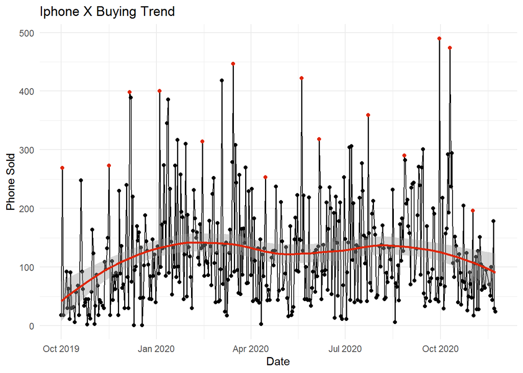

```r
library(lubridate)
library(ggplot2)

plot_trend <- new_nonmul_rev %>%
  filter(Product %in% unique(desc_clean$Name)) %>%
  mutate(date = date(ymd_hm(Time))) %>%
  group_by(date) %>%
  summarise(phone_sold = n()) %>%
  mutate(month = month(date,label = T),
         year = year(date)) %>%
  group_by(month,year) %>%
  mutate(ismax = max(phone_sold),
         ismax = ifelse(phone_sold==ismax,T,F)) %>%
  ggplot(aes(x = date, y = phone_sold)) +
  geom_line(aes(group = 1)) +
  geom_point(aes(col = ismax),show.legend = F) +
  geom_smooth(col = "#e02509",method = "loess") +
  scale_color_manual(values = c("black","#e02509")) +
  labs(title = "Iphone X Buying Trend",
       x = "Date",y = "Phone Sold") +
  theme_minimal()

plot_trend
```

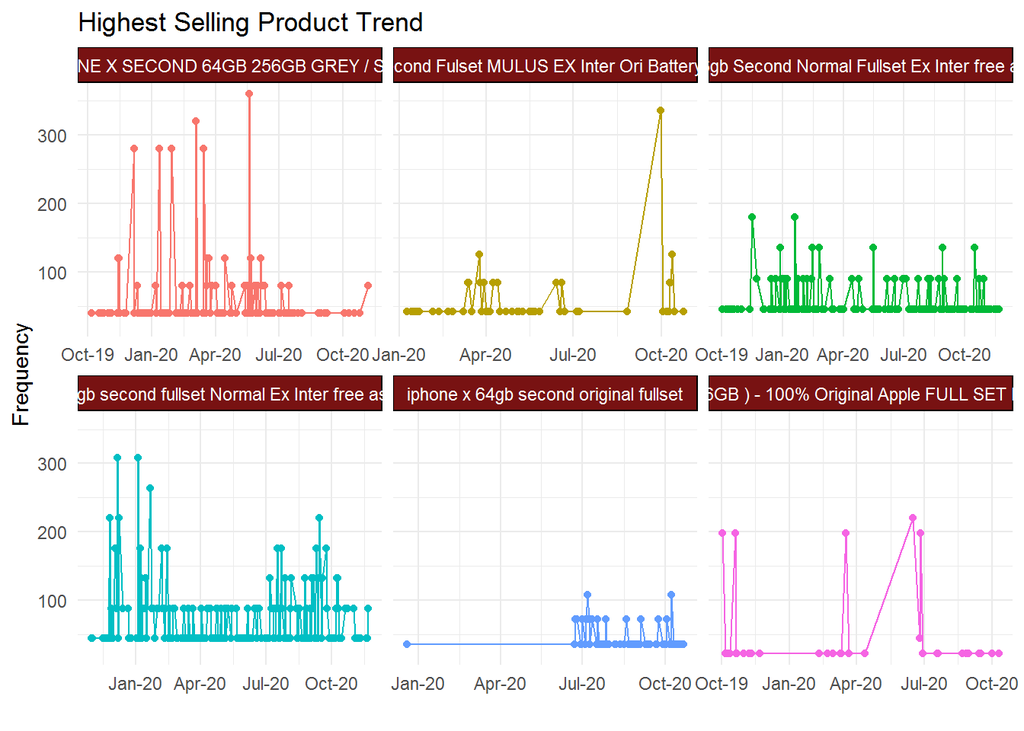

```r
most_product <- new_nonmul_rev %>%
  filter(Product %in% unique(desc_clean$Name)) %>%
  mutate(date = date(ymd_hm(Time))) %>%
  group_by(Product) %>%
  summarise(f = n()) %>%
  arrange(-f) %>%
  head(6) %>%
  pull(Product)

new_nonmul_rev %>%
  filter(Product %in% most_product) %>%
  mutate(date = date(ymd_hm(Time))) %>%
  group_by(date,Product) %>%
  summarise(freq = n()) %>%
  arrange() %>%
  # padr::pad(start_val = as.Date("2019-10-01"),end_val = as.Date("2020-11-23"),
  #           group = "Product",interval = "day") %>%
  # mutate(freq = replace_na(freq,0)) %>%
  ggplot(aes(x = date, y = freq,group = Product, col = Product)) +
  geom_line() + geom_point() +
  scale_x_date(date_labels = "%b-%y") +
  theme_minimal() +
  facet_wrap(~Product,scales = "free_x") +
  labs(title = "Highest Selling Product Trend",
       x = "", y = "Frequency") +
  theme(legend.position = "none",
        strip.background = element_rect(fill = "#781212"),
        strip.text.x = element_text(colour = "white"))
```

Best product with highest positive sentiment

```r
library(textclean)
library(stringr)
library(katadasaR)
library(tm)
library(SnowballC)

# slang word indo
indo_stem <- read.csv("data_input/colloquial-indonesian-lexicon.csv")

# add custom bahasa stopwords
bahasa.sw <- read.csv("data_input/Bahasa.stopwords.csv", header = F,fileEncoding = "UTF-8-BOM")
bahasa.sw <- as.character(bahasa.sw$V1)
bahasa.sw <- c(bahasa.sw, stopwords())

# senti-strength bahasa score
bahasa.sentiment <- read.delim("data_input/sentiwords_id.txt",sep = ":",header = F)
bahasa.sentiment <- bahasa.sentiment %>% setNames(c("words","weight")) %>%
  mutate(words = str_trim(words))
```

text cleaner

```r
# stemming function using package katadasaR
stemming_bahasa <- function(x){
  paste(lapply(x,katadasar),collapse = " ")
}

# function textcleaner
textcleaner <- function(x){
  x <- as.character(x)

  x <- x %>%
    str_to_lower() %>%  # convert all the string to low alphabet
    replace_contraction() %>% # replace contraction to their multi-word forms
    replace_internet_slang() %>% # replace internet slang to normal words
    replace_emoji() %>% # replace emoji to words
    replace_emoticon() %>% # replace emoticon to words
    replace_hash(replacement = "") %>% # remove hashtag
    replace_word_elongation() %>% # replace informal writing with known semantic replacements
    replace_internet_slang(slang = paste0("\\b",
                                          indo_stem$slang,"\\b"),
                           replacement = indo_stem$formal,ignore.case = T) %>%  # bahasa slang word
    lapply(stemming_bahasa) %>% # bahasa stemming
    replace_number(remove = T) %>% # remove number
    replace_date(replacement = "") %>% # remove date
    replace_time(replacement = "") %>% # remove time
    str_replace_all(pattern = "[[:punct:]]",replacement = " ") %>% # remove punctuation
    str_replace_all(pattern = "[^\\s]*[0-9][^\\s]*",replacement = " ") %>% # remove mixed string n number
    removeWords(bahasa.sw) %>% # apply bahasa stopwords
    str_squish() %>% # reduces repeated whitespace inside a string.
    str_trim() # removes whitespace from start and end of string

  return(as.data.frame(x))
}
```

```r
review_filter <- new_nonmul_rev %>%
  filter(Product %in% unique(desc_clean$Name))

clean_review <- textcleaner(review_filter$Review)
```

```r
clean_review <- data.frame()
for(i in 1:nrow(review_filter)){
  message("Cleaning",i,"/",nrow(review_filter))
  temp_clean <- textcleaner(review_filter$Review[i])

  clean_review <-  rbind(clean_review,temp_clean)
}
```

```r
saveRDS(clean_review,"review_clean.rds")
```